# Hearthstone Arena Card Recommendation Model

Seokin Seo

August 16, 2016

# Introduction

## Hearthstone과 Arena

하스스톤은 Blizzard Entertainment에서 개발한 온라인 기반 트레이딩 카드 게임이다. 그 중에서 투기장(Arena)이란 시스템이 제공되는데, 투기장은 플레이어가 가지고 있는 덱을 사용하는 것이 아니라, 랜덤하게 제시되는 3장의 카드 중 1장의 카드를 골라서 총 30장의 덱을 구성하여 진행하는 방식을 말한다.

## Goal

투기장에서 플레이어는 어떤 카드를 가지고 플레이할지 예상하기 어려우므로, 그때 그때 제시되는 카드를 보다 잘 선택(Pick)할 필요성이 있고, 이러한 선택을 통계와 데이터 사이언스에 기반하여 추천하는 것이 이 프로젝트의 목적이다.

# Dataset Description

## Used Libraries

```r
library(ggplot2)
library(dplyr)
library(ROCR)
library(stringr)
library(glmnet)
library(randomForest)
library(gbm)
library(editR)
```

## cardinfo

투기장에서 사용되는 카드들의 정보들을 담고 있는 데이터셋으로 `cardinfo_collect.csv`로부터 필요한 변수들들을 선택하여 `cardinfo` 데이터프레임으로 삽입한다.

```r
cardinfo_collect <- read.csv("cardinfo_collect.csv", header = TRUE, na.string="")
cardinfo <- cardinfo_collect %>% select(name,type,rarity,playerClass,cost,attack,health,race,text,spellDamage,overload)
cardinfo <- cardinfo
```

```r
head(cardinfo)
```

```
##                name   type    rarity playerClass cost attack health   race
## 1        Drain Life  SPELL      FREE     WARLOCK    3     NA     NA   <NA>
## 2      Sense Demons  SPELL    COMMON     WARLOCK    3     NA     NA   <NA>
## 3        Dreadsteed MINION      EPIC     WARLOCK    4      1      1  DEMON
## 4         The Beast MINION LEGENDARY        <NA>    6      9      7  BEAST
## 5 Murloc Tidecaller MINION      RARE        <NA>    1      1      2 MURLOC
## 6        Inner Rage  SPELL    COMMON     WARRIOR    0     NA     NA   <NA>
##                                                                 text
## 1                     Deal 2 damage. Restore #2 Health to your hero.
## 2                 Put 2 random Demons from your deck into your hand.
## 3                           <b>Deathrattle:</b> Summon a Dreadsteed.
## 4 <b>Deathrattle:</b> Summon a 3/3 Finkle Einhorn for your opponent.
## 5                     Whenever a Murloc is summoned, gain +1 Attack.
## 6                   Deal 1 damage to a minion and give it +2 Attack.
##   spellDamage overload
## 1          NA       NA
## 2          NA       NA
## 3          NA       NA
## 4          NA       NA
## 5          NA       NA
## 6          NA       NA
```

[figure not shown]

**Variables**

- name : 카드의 이름
- type : 카드의 종류. 크게 **하수인**과 **주문**으로 나뉜다.
- rarity : 카드의 희귀도. **전설, 영웅, 희귀, 일반**으로 나뉜다.
- playerClass : 직업에 따라 사용할수 있는 카드가 다른 경우 어떤 직업인지 나타낸다.
- cost : 카드의 비용. 좌측 상단에 있는 숫자를 나타낸다.
- attack : 하수인의 공격력
- health : 하수인의 체력
- race : 하수인의 종족. 없는 경우가 더많다.
- text : 카드의 텍스트
- spellDamage : 주문공격력
- overload : 과부하

## arenainfo

투기장에서 플레이한 플레이어들의 정보들을 담고 있는 데이터셋으로, 그중에서도 10승 이상을 거둔 플레이어들의 정보를 담고 있는 데이터셋으로 그 범위를 축소시켰다. 전체 데이터의 메타데이터를 담고 있는 `arena_info.csv` 파일과 각각의 직업별로 어떤 카드들을 선택했는지에 관한 데이터를 담고 있는 `arena_druid.csv`, `arena_hunter.csv`, `arena_mage.csv` 등의 파일이 있다.

```r
arenainfo <- read.csv( "arena_info.csv",    header= TRUE )
druid     <- read.csv( "arena_druid.csv",   header= TRUE )
hunter    <- read.csv( "arena_hunter.csv",  header= TRUE )
mage      <- read.csv( "arena_mage.csv",    header= TRUE )
paladin   <- read.csv( "arena_paladin.csv", header= TRUE )
priest    <- read.csv( "arena_priest.csv",  header= TRUE )
rogue     <- read.csv( "arena_rogue.csv",   header= TRUE )
shaman    <- read.csv( "arena_shaman.csv",  header= TRUE )
warlock   <- read.csv( "arena_warlock.csv", header= TRUE )
warrior   <- read.csv( "arena_warrior.csv", header= TRUE )
```

```r
head(arenainfo)
```

```
##     Class Total.Decks X10.More.Wins   Rate
## 1   Druid       11929           611 0.0512
## 2  Hunter        5564           318 0.0572
## 3    Mage       20480          1746 0.0853
## 4 Paladin       15177          1003 0.0661
## 5  Priest        6434           306 0.0476
## 6   Rogue       10097           674 0.0668
```

```r
head(druid)
```

```
##                name cnt frequency allfrequency  diff
## 1       Abomination  46      0.08         0.10 -0.02
## 2  Abusive Sergeant  57      0.09         0.10 -0.01
## 3 Acidic Swamp Ooze 256      0.42         0.45 -0.03
## 4   Acolyte of Pain 123      0.20         0.22 -0.02
## 5       Alarm-o-Bot   1      0.00         0.01 -0.01
## 6   Amani Berserker 172      0.28         0.28  0.00
```

# Data Preprocessing

카드를 추천하기 위해서는 해당 카드가 어떤 기능이 있고, 어떤 장단점이 있는지 파악하는 것이 중요한데, 이를 파악하기 위해 카드의 텍스트를 살펴볼 필요가 있다. 우선 텍스트에서 각각의 조건에 맞는 attribute를 추출하기 위해서 `text` attribute가 NA인 경우 null string (“”)으로 교체한다.

```r
levels(cardinfo$text) <- append(levels(cardinfo$text), "")
for(idx in which(is.na(cardinfo$text)))
  cardinfo[idx,"text"] <- ""
```

위 작업을 거친 후, 각각의 attribute들을 `text` attribute로부터 추출하고 `mutate` 함수를 이용하여 `cardinfo` 데이터프레임에 삽입한다.

```r
# Card Information Pre-processing
cardinfo <- cardinfo %>% filter( type!="HERO" ) %>%
  mutate( hasTaunt        = as.numeric( str_detect( text,"Taunt") ) ) %>%
  mutate( hasCharge       = as.numeric( str_detect( text,"Charge") ) ) %>%
  mutate( hasDeathrattle  = as.numeric( str_detect( text,"Deathrattle") ) ) %>%
  mutate( hasBattlecry    = as.numeric( str_detect( text,"Battlecry") ) ) %>%
  mutate( hasDivineShield = as.numeric( str_detect( text,"Divine Shield") ) ) %>%
  mutate( hasStealth      = as.numeric( str_detect( text,"Stealth") ) ) %>%
  mutate( hasWindfury     = as.numeric( str_detect( text,"Windfury") ) )%>%
  mutate( isSecret        = as.numeric( ( type=="SPELL" & str_detect(text,"Secret") ) ) )%>%
  mutate( hasCombo        = as.numeric( str_detect( text,"Combo") ) ) %>%
  mutate( hasDestroy      = as.numeric( str_detect( text,"Destroy") ) ) %>%
  mutate( hasInspire      = as.numeric( str_detect( text,"Inspire") ) ) %>%
  mutate( hasFreeze       = as.numeric( str_detect( text,"Freeze") ) ) %>%
  mutate( hasDraw         = as.numeric( str_detect( text,"Draw") ) ) %>%
  mutate( hasDiscard      = as.numeric( str_detect( text,"Discard") ) ) %>%
  mutate( hasChoose       = as.numeric( str_detect( text,"Choose One") ) ) %>%
  mutate( relSummon       = as.numeric( str_detect( text,"Summon ") ) ) %>%
  mutate( affectToAll     = as.numeric( str_detect( text,"to all ") ) ) %>%
  mutate( restoreAmount   = ifelse( str_detect( text,"Restore" ), as.integer(str_extract(text, "[0-9]+")) , 0 ) ) %>%
  mutate( dealAmount      = ifelse( str_detect( text,"Deal" ),    as.integer(str_extract(text, "[0-9]+")) , 0 ) ) %>%
  transform( name = as.character(name) ) %>% select(-text) %>% arrange( as.character(name) )
```

추후에 모델링을 위해 boolean 자료형이 아니라 numeric으로 타입캐스팅했다. 위 과정을 거친 후에도 남아있는 NA값들의 값들을 지정해준다.

```r
# NA Processing
levels(cardinfo$playerClass) <- append(levels(cardinfo$playerClass), "COMMON")
for(idx in which(is.na(cardinfo$playerClass)))
  cardinfo[idx,"playerClass"] <- "COMMON"

levels(cardinfo$race) <- append(levels(cardinfo$race), "NORMAL")
for(idx in which(is.na(cardinfo$race)))
  cardinfo[idx,"race"] <- "NORMAL"

cardinfo[is.na(cardinfo)] <- 0
```

또한 투기장 데이터들도 preprocessing한다.

```r
overall <- data.frame( name=character(), cnt=integer(), freqeuncy=numeric(),
                       allfrequency=numeric(), diff=numeric(), className=character() )

druid   <- druid %>% mutate(className = "Druid") %>% arrange(desc(frequency))
hunter  <- hunter %>% mutate(className = "Hunter") %>% arrange(desc(frequency))
mage    <- mage %>% mutate(className = "Mage") %>% arrange(desc(frequency))
paladin <- paladin %>% mutate(className = "Paladin") %>% arrange(desc(frequency))
priest  <- priest %>% mutate(className = "Priest") %>% arrange(desc(frequency))
rogue   <- rogue %>% mutate(className = "Rogue") %>% arrange(desc(frequency))
shaman  <- shaman %>% mutate(className = "Shaman") %>% arrange(desc(frequency))
warlock <- warlock %>% mutate(className = "Warlock") %>% arrange(desc(frequency))
warrior <- warrior %>% mutate(className = "Warrior") %>% arrange(desc(frequency))

classlist = list(druid,hunter,mage,paladin,priest,rogue,shaman,warlock,warrior)
```

## 자료시각화

### 직업별 빈도수 Top 15

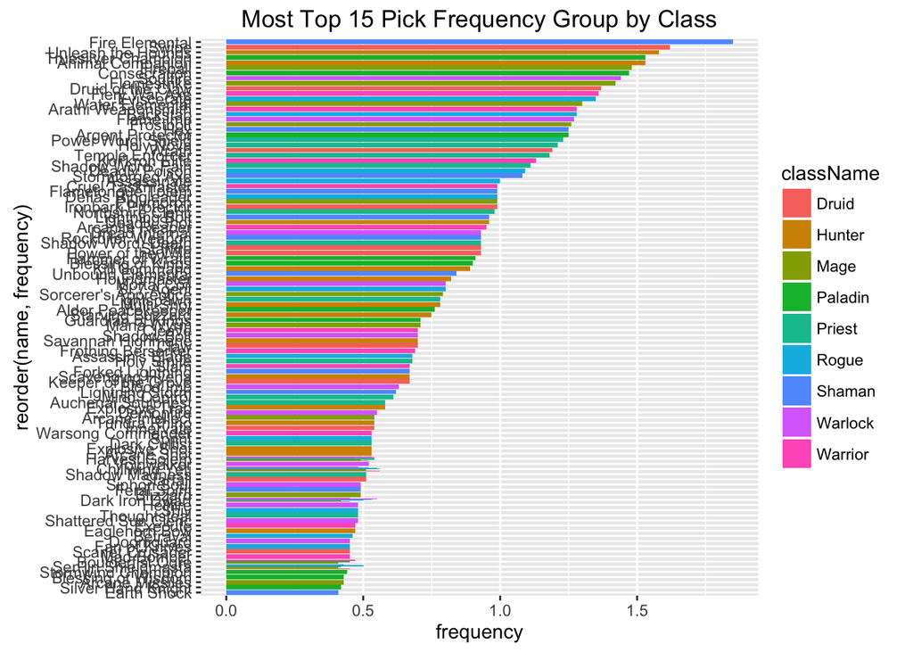

## 투기장 전체 Top 50

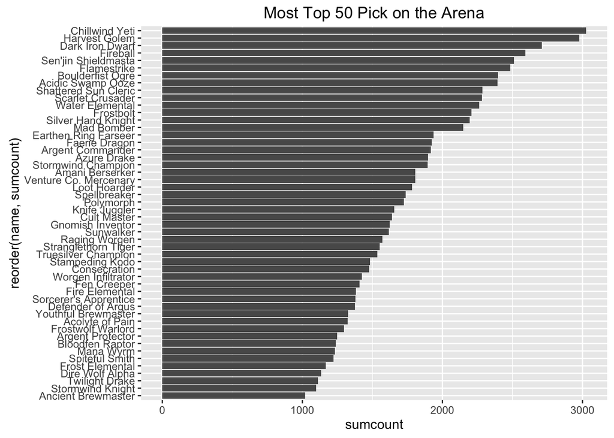

# Data Modeling

각각 직업마다 데이터 모델링을 해야 하지만, 이번 프로젝트에서는 우선 마법사 직업의 데이터셋만 다루기로 한다. 따라서 `result_mage` 데이터셋을 `playerClass`가 `'MAGE'`또는 `'COMMON'`인 카드들로만 필터링한다.

```r
# Make Model for Mage Class
result_mage <- left_join(cardinfo, mage[1:4])
result_mage[is.na(result_mage)] <- 0
result_mage <- result_mage %>% filter( playerClass=='MAGE' | playerClass=='COMMON' )
```

## Frequency Normalization

투기장에서 일반 등급의 카드가 등장할 확률과 전설 등급의 카드가 등장할 확률은 같지 않으므로 이를 일반화해서 모델링 하여야 한다. 예를 들어, 나쁘지 않지만 자주 등장하기 때문에 자주 고르는 일반 카드가 있고, 자주 등장하지는 않지만 나오면 무조건 고르는 것이 승률에 영향을 주는 전설 카드의 경우 후자의 카드가 더 중요하다고 볼 수 있으므로 이를 일반화 시켜주어야 한다.

```r
# Rarity Normalize
leg  <- as.integer(sum( result_mage %>% filter(rarity=='LEGENDARY') %>% select(cnt) ))
epic <- as.integer(sum( result_mage %>% filter(rarity=='EPIC') %>% select(cnt) ))
rare <- as.integer(sum( result_mage %>% filter(rarity=='RARE') %>% select(cnt) ))
com  <- as.integer(sum( result_mage %>% filter(rarity=='COMMON' | rarity=='FREE') %>% select(cnt) ))

sumr <- as.integer( sum(c(leg,epic,rare,com)) )
legr <- leg/sumr
epicr <- epic/sumr
rarer <- rare/sumr
comr <- com/sumr

result_mage <- result_mage %>%
  mutate( normfreq = frequency / ifelse( rarity=='LEGENDARY', legr,
                                  ifelse( rarity=='EPIC', epicr,
                                    ifelse( rarity=='RARE', rarer, comr) ) ) )
```

## Setting Target Attribute

어떤 변수를 대응변수로 설정할지 정한다. 앞서 normalize한 결과를 토대로, 그 결과가 평균결과보다 높은지 분류분석하기로 하자. 해당 대응변수를 `freqover`라고 명명했다.

```r
# Set target attribute (freqover)
freqthres <- as.numeric(result_mage %>% summarize(mean(normfreq)))
result_mage <- result_mage %>%
  mutate( freqover = ifelse(normfreq >= freqthres, "Y", "N") )
result_mage$freqover <- as.factor(result_mage$freqover)
```

## Data Sampling

위에서 생성된 데이터를 6:2:2 비율로 각각 `train_set`, `validate_set`, `test_set`으로 샘플링한다.

```r
# Sampling Set
set.seed(1601)
n <- nrow(result_mage)

idx <- 1:n
training_idx <- sample(idx, n * .60)
idx <- setdiff(idx, training_idx)
validate_idx = sample(idx, n * .20)
test_idx <- setdiff(idx, validate_idx)

length(training_idx)
```

```
## [1] 202
```

```r
length(validate_idx)
```

```
## [1] 67
```

```r
length(test_idx)
```

```
## [1] 68
```

```r
train_set    <- result_mage[training_idx,]
validate_set <- result_mage[validate_idx,]
test_set     <- result_mage[test_idx,]
```

## Visualization

위 결과를 간단히 시각화한 결과는 다음과 같다.

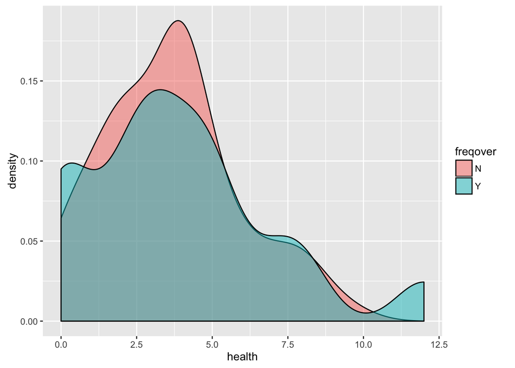

```r
levels(train_set$name) <- levels(result_mage$name)
levels(validate_set$name) <- levels(result_mage$name)
levels(test_set$name) <- levels(result_mage$name)

train_set %>%
  ggplot(aes(health, fill=freqover)) + geom_density(alpha=.5)
```

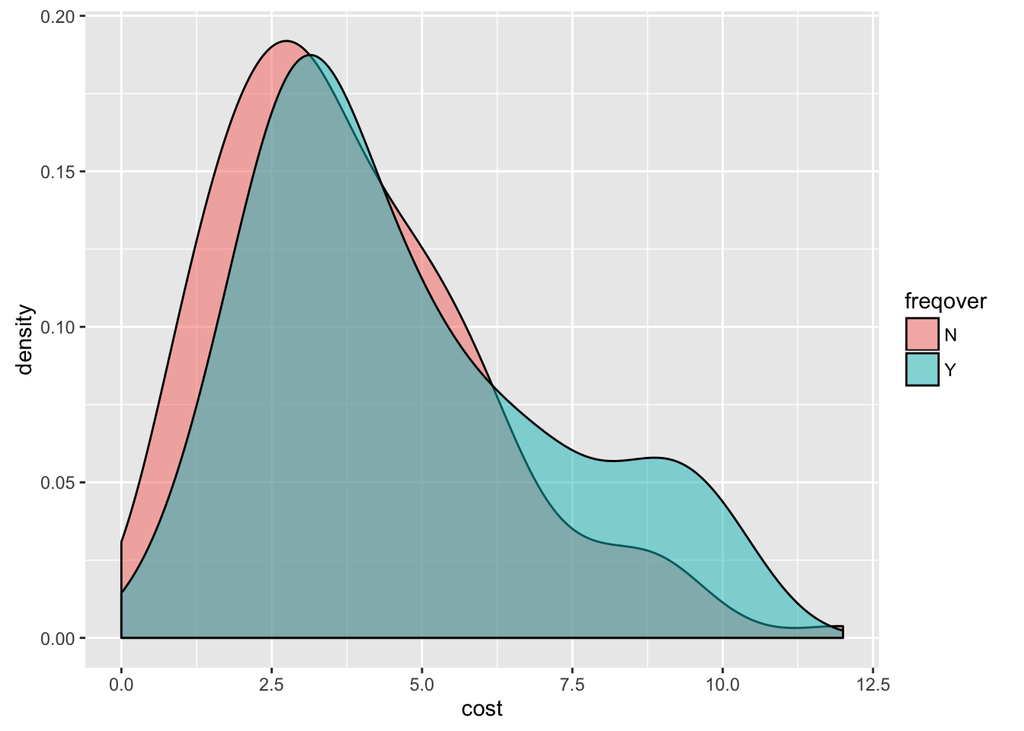

```r
train_set %>%
  ggplot(aes(cost, fill=freqover)) + geom_density(alpha=.5)
```

# Classification Modeling

## Generalized Linear Model

```r
# Generalized Linear Model
glm_full = glm(freqover ~ +rarity +type +race +health +attack +cost +dealAmount +restoreAmount
               +spellDamage +overload +hasTaunt +hasCharge +hasBattlecry +hasDivineShield
               +hasDeathrattle +hasStealth +hasWindfury +isSecret +hasCombo +hasDestroy +hasInspire
               +hasFreeze +hasDraw +hasDiscard +hasChoose +relSummon +affectToAll, data=train_set, family=binomial)
summary(train_set)
```

```
##      name               type           rarity    playerClass
##  Length:202         HERO  :  0   COMMON   :85   COMMON :170
##  Class :character   MINION:181   EPIC     :22   MAGE   : 32
##  Mode  :character   SPELL : 21   FREE     :14   DRUID  :  0
##                     WEAPON:  0   LEGENDARY:41   HUNTER :  0
##                                  RARE     :40   PALADIN:  0
##                                                 PRIEST :  0
##                                                 (Other):  0
##       cost            attack           health               race
##  Min.   : 0.000   Min.   : 0.000   Min.   : 0.000   NORMAL    :148
##  1st Qu.: 2.000   1st Qu.: 1.000   1st Qu.: 2.000   BEAST     : 16
##  Median : 4.000   Median : 3.000   Median : 4.000   MECHANICAL: 14
##  Mean   : 4.064   Mean   : 3.213   Mean   : 3.718   DRAGON    : 13
##  3rd Qu.: 5.000   3rd Qu.: 5.000   3rd Qu.: 5.000   PIRATE    :  6
##  Max.   :12.000   Max.   :12.000   Max.   :12.000   MURLOC    :  4
##                                                     (Other)   :  1
##   spellDamage         overload    hasTaunt         hasCharge
##  Min.   :0.00000   Min.   :0   Min.   :0.00000   Min.   :0.00000
##  1st Qu.:0.00000   1st Qu.:0   1st Qu.:0.00000   1st Qu.:0.00000
##  Median :0.00000   Median :0   Median :0.00000   Median :0.00000
##  Mean   :0.05446   Mean   :0   Mean   :0.08911   Mean   :0.04455
##  3rd Qu.:0.00000   3rd Qu.:0   3rd Qu.:0.00000   3rd Qu.:0.00000
##  Max.   :5.00000   Max.   :0   Max.   :1.00000   Max.   :1.00000
##
##  hasDeathrattle     hasBattlecry    hasDivineShield    hasStealth
##  Min.   :0.00000   Min.   :0.0000   Min.   :0.0000   Min.   :0.00000
##  1st Qu.:0.00000   1st Qu.:0.0000   1st Qu.:0.0000   1st Qu.:0.00000
##  Median :0.00000   Median :0.0000   Median :0.0000   Median :0.00000
##  Mean   :0.09406   Mean   :0.2921   Mean   :0.0297   Mean   :0.01485
##  3rd Qu.:0.00000   3rd Qu.:1.0000   3rd Qu.:0.0000   3rd Qu.:0.00000
##  Max.   :1.00000   Max.   :1.0000   Max.   :1.0000   Max.   :1.00000
##
##   hasWindfury        isSecret          hasCombo   hasDestroy
##  Min.   :0.0000   Min.   :0.00000   Min.   :0   Min.   :0.00000
##  1st Qu.:0.0000   1st Qu.:0.00000   1st Qu.:0   1st Qu.:0.00000
##  Median :0.0000   Median :0.00000   Median :0   Median :0.00000
##  Mean   :0.0297   Mean   :0.02475   Mean   :0   Mean   :0.02475
##  3rd Qu.:0.0000   3rd Qu.:0.00000   3rd Qu.:0   3rd Qu.:0.00000
##  Max.   :1.0000   Max.   :1.00000   Max.   :0   Max.   :1.00000
##
```

[output cut: 17 more lines]

```
##  Min.   : 0.0000   Min.   :   0.0   Min.   :0.0000   Min.   :0.0000
##  1st Qu.: 0.0000   1st Qu.:   0.0   1st Qu.:0.0000   1st Qu.:0.0000
##  Median : 0.0000   Median :  12.5   Median :0.0100   Median :0.0100
##  Mean   : 0.2921   Mean   : 178.0   Mean   :0.1019   Mean   :0.1005
##  3rd Qu.: 0.0000   3rd Qu.: 174.2   3rd Qu.:0.0975   3rd Qu.:0.1200
##  Max.   :10.0000   Max.   :2591.0   Max.   :1.4800   Max.   :1.2100
##
##     normfreq       freqover
##  Min.   :0.00000   N:148
##  1st Qu.:0.00000   Y: 54
##  Median :0.01272
##  Mean   :0.40406
##  3rd Qu.:0.40714
##  Max.   :8.17491
##
```

```r
y_obs = ifelse(validate_set$normfreq >= freqthres, "Y", "N")
y_obs <- as.factor(y_obs)
yhat_lm = predict(glm_full, newdata=validate_set, type='response')
```

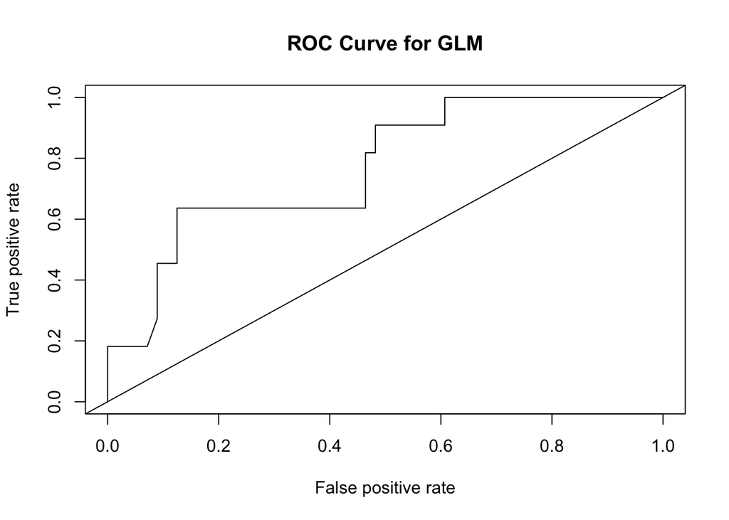

```r
pred_lm = prediction(yhat_lm, y_obs)
perf_lm = performance(pred_lm, measure = "tpr", x.measure = "fpr")
plot(perf_lm, col='black', main="ROC Curve for GLM")
abline(0,1)
```

## Glmnet

```r
# Glmnet
xx = model.matrix(freqover ~ +rarity +type +race +health +attack +cost +dealAmount +restoreAmount
                  +spellDamage +overload +hasTaunt +hasCharge +hasBattlecry +hasDivineShield
                  +hasDeathrattle +hasStealth +hasWindfury +isSecret +hasCombo +hasDestroy +hasInspire
                  +hasFreeze +hasDraw +hasDiscard +hasChoose +relSummon +affectToAll -1, result_mage)
x = xx[training_idx, ]
y = ifelse(train_set$freqover  == "Y", 1, 0)
dim(x)
```

```
## [1] 202  39
```

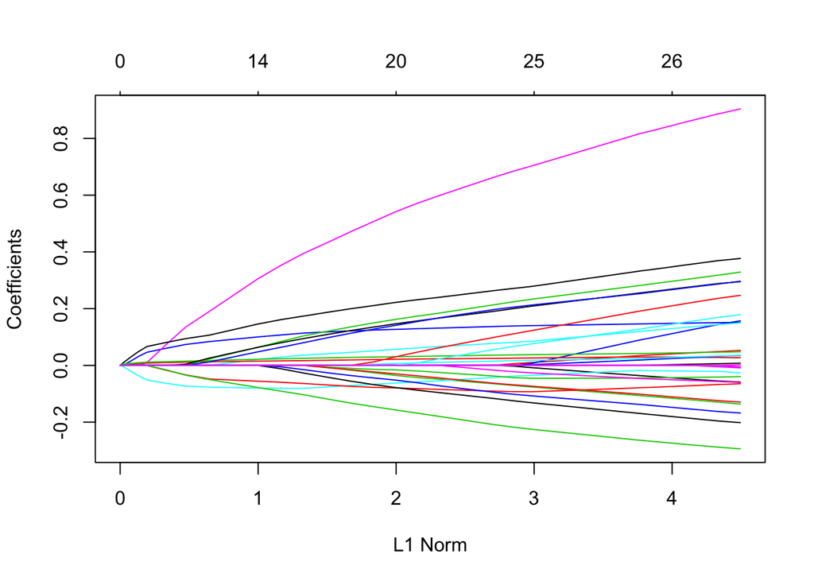

```r
hs_glmnet_fit = glmnet(x, y)
plot(hs_glmnet_fit)
```

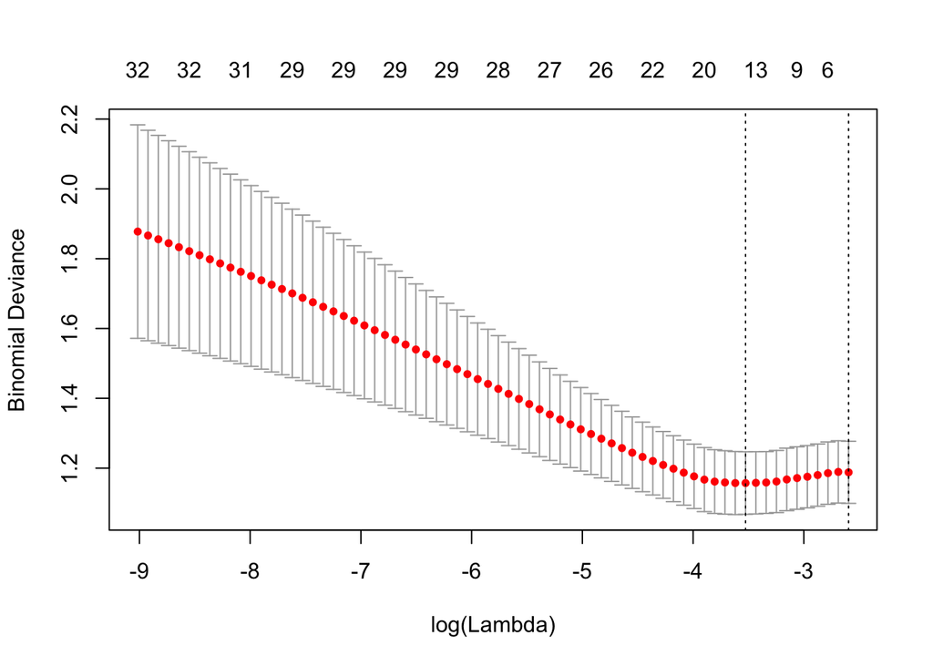

```r
hs_cvfit = cv.glmnet(x, y, family = "binomial")
plot(hs_cvfit)
```

```r
log(hs_cvfit$lambda.min)
```

```
## [1] -3.526314
```

```r
coef(hs_cvfit, s=hs_cvfit$lambda.min)
```

```
## 40 x 1 sparse Matrix of class "dgCMatrix"
##                             1
## (Intercept)     -1.327282e+00
## rarityCOMMON     .
## rarityEPIC       .
## rarityFREE       .
## rarityLEGENDARY  .
## rarityRARE       5.437953e-01
## typeMINION      -4.128076e-01
## typeSPELL        3.693679e-14
## typeWEAPON       .
## raceDEMON        1.583168e+00
## raceDRAGON       7.705605e-01
## raceMECHANICAL  -3.270347e-01
## raceMURLOC       .
## racePIRATE       .
## raceTOTEM        .
## raceNORMAL       1.883970e-01
## health           .
## attack           .
## cost             8.196813e-02
## dealAmount       9.656089e-02
## restoreAmount    .
## spellDamage      .
## overload         .
## hasTaunt         .
## hasCharge       -7.764135e-02
## hasBattlecry     .
## hasDivineShield  4.102577e-01
## hasDeathrattle  -3.246104e-02
## hasStealth       .
## hasWindfury      .
## isSecret         3.282369e-01
## hasCombo         .
## hasDestroy       .
## hasInspire      -5.973117e-01
## hasFreeze        .
## hasDraw          3.049038e-01
## hasDiscard       .
## hasChoose        .
## relSummon        .
## affectToAll      .
```

```r
length(which(coef(hs_cvfit, s="lambda.min")>0))
```

```
## [1] 10
```

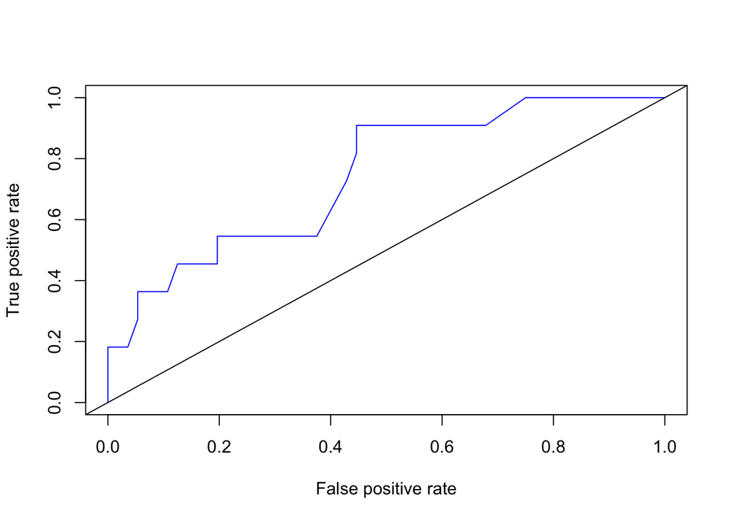

```r
y_obs = ifelse(validate_set$freqover == "Y", 1, 0)
yhat_glmnet = predict(hs_cvfit, s = "lambda.min", newx=xx[validate_idx,], type='response')
# yhat_glmnet = predict(ad_cvfit, s = "lambda.min", newx=xx[validate_idx,], type='response')
yhat_glmnet = yhat_glmnet[,1] # change to a vectro from [n*1] matrix

pred_glmnet = prediction(yhat_glmnet, y_obs)
perf_glmnet = performance(pred_glmnet, measure = "tpr", x.measure = "fpr")
plot(perf_glmnet, col='blue')
abline(0,1)
```

## Random Forest

```r
# Random Forest
set.seed(1607)
ad_rf = randomForest(freqover ~ +rarity +type +race +health +attack +cost +dealAmount +restoreAmount
                     +spellDamage +overload +hasTaunt +hasCharge +hasBattlecry +hasDivineShield
                     +hasDeathrattle +hasStealth +hasWindfury +isSecret +hasCombo +hasDestroy +hasInspire
                     +hasFreeze +hasDraw +hasDiscard +hasChoose +relSummon +affectToAll, train_set)
ad_rf
```

```
##
## Call:
##  randomForest(formula = freqover ~ +rarity + type + race + health +      attack + cost + dealAmount + restoreAmount + spellDamage +      overload + hasTaunt + hasCharge + hasBattlecry + hasDivineShield +      hasDeathrattle + hasStealth + hasWindfury + isSecret + hasCombo +      hasDestroy + hasI…
##                Type of random forest: classification
##                      Number of trees: 500
## No. of variables tried at each split: 5
##
##         OOB estimate of  error rate: 30.2%
## Confusion matrix:
##     N  Y class.error
## N 136 12  0.08108108
## Y  49  5  0.90740741
```

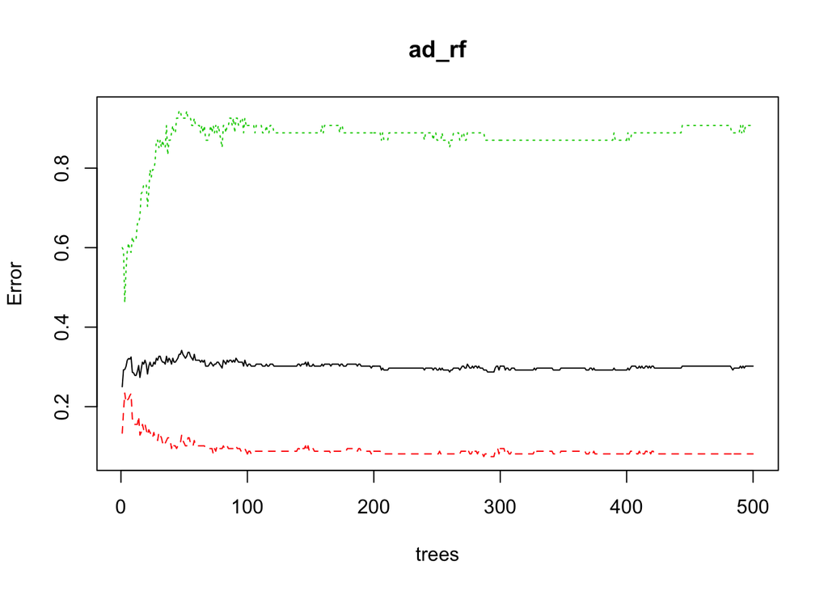

```r
 plot(ad_rf)
```

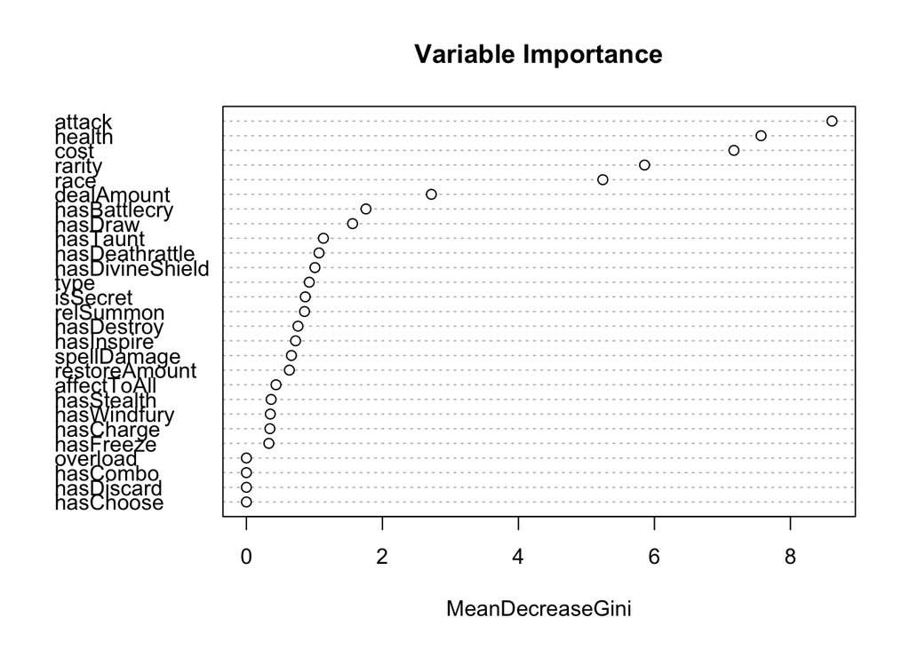

```r
varImpPlot(ad_rf, main="Variable Importance")
```

```r
test_set[1:5,"name"]
```

```
## [1] "Ancient Mage"     "Antique Healbot"  "Big Game Hunter"
## [4] "Bloodfen Raptor"  "Bluegill Warrior"
```

```r
predict(ad_rf, newdata = test_set[1:5,],type="prob")
```

```
##        N     Y
## 9  0.816 0.184
## 13 0.746 0.254
## 30 0.750 0.250
## 36 0.810 0.190
## 40 0.986 0.014
## attr(,"class")
## [1] "matrix" "votes"
```

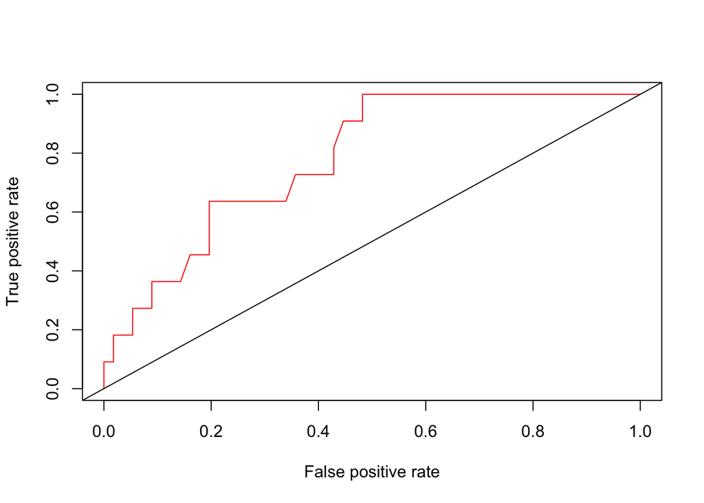

```r
yhat_rf = predict(ad_rf, newdata = validate_set, type='prob')[,'Y']
pred_rf = prediction(yhat_rf, y_obs)
perf_rf = performance(pred_rf, measure = "tpr", x.measure = "fpr")
plot(perf_rf, col='red')
abline(0,1)
```

## GBM Boosting

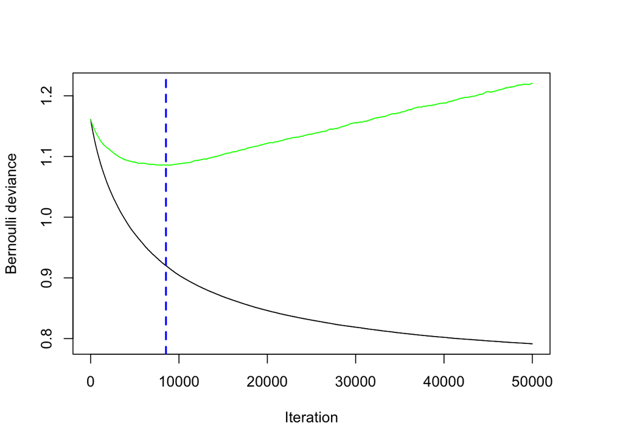

```r
# GBM Boosting
set.seed(1607)
result_gbm = train_set %>% mutate(freqover=ifelse(freqover == "Y", 1, 0))

re_gbm = gbm(freqover ~ +rarity +type +race +health +attack +cost +dealAmount +restoreAmount
             +spellDamage +overload +hasTaunt +hasCharge +hasBattlecry +hasDivineShield
             +hasDeathrattle +hasStealth +hasWindfury +isSecret +hasCombo +hasDestroy +hasInspire
             +hasFreeze +hasDraw +hasDiscard +hasChoose +relSummon +affectToAll, data=result_gbm,
             distribution = "bernoulli",
             n.trees=50000, cv.folds=3, verbose = TRUE)
best_iter = gbm.perf(re_gbm, method="cv")
```

```r
re_gbm2 = gbm.more(re_gbm, n.new.trees = 10000)
best_iter = gbm.perf(re_gbm2, method="cv")
```

[figure not shown]

```r
yhat_gbm = predict(re_gbm, n.trees=best_iter, newdata=validate_set, type='response')
pred_gbm = prediction(yhat_gbm, y_obs)
perf_gbm = performance(pred_gbm, measure = "tpr", x.measure = "fpr")
```

## Performance Report

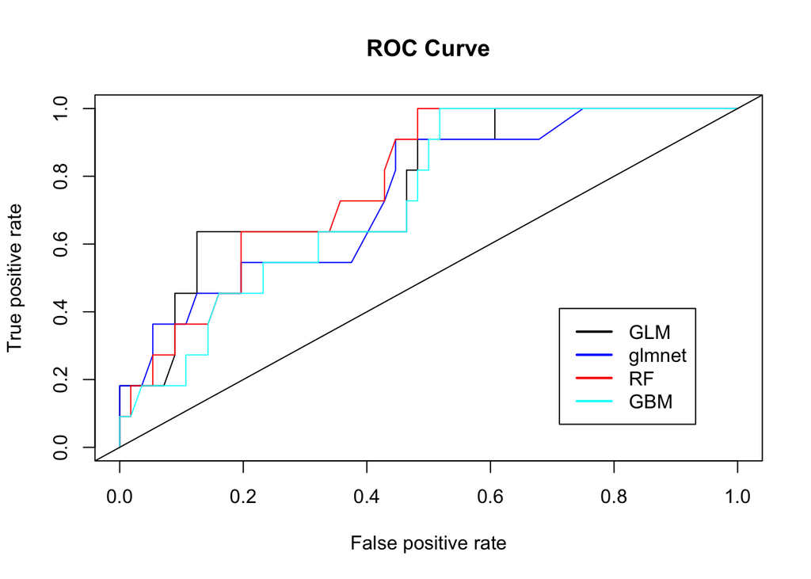

```r
plot(perf_lm, col='black', main="ROC Curve")
plot(perf_glmnet, add=TRUE, col='blue')
plot(perf_rf, add=TRUE, col='red')
plot(perf_gbm, add=TRUE, col='cyan')
abline(0,1)

legend('bottomright', inset=.1,
         legend = c("GLM", "glmnet", "RF", "GBM"),
         col=c('black', 'blue', 'red', 'cyan'), lty=1, lwd=2)
```

```r
performance(pred_lm, "auc")@y.values[[1]]
```

```
## [1] 0.7702922
```

```r
performance(pred_glmnet, "auc")@y.values[[1]]
```

```
## [1] 0.7443182
```

```r
performance(pred_rf, "auc")@y.values[[1]]
```

```
## [1] 0.7816558
```

```r
performance(pred_gbm, "auc")@y.values[[1]]
```

```
## [1] 0.7321429
```

```r
# Predict by GBM Model
predict(re_gbm, n.trees=best_iter, newdata=result_gbm %>% filter(name=='Fireball'), type='response')
```

```
## [1] 0.4966692
```